# SCFA_Spearman_Correlation_Plots

Anna Michl

2026-01-27

Load all packages needed

```r
library(dplyr)
```

```r
library(readxl)
library(ggplot2)
library(ggpubr)  # for stats annotations
library(dplyr)
library(ggrepel)
library(tidyr)
library(patchwork)
```

Set working directory (ADJUST TO YOUR PATH TO THE .XLSX FILE)

```r
setwd("C:/Users/annaj/Desktop/SCFAs_interlab_validation")
R.version
```

```
##                _
## platform       x86_64-w64-mingw32
## arch           x86_64
## os             mingw32
## crt            ucrt
## system         x86_64, mingw32
## status
## major          4
## minor          4.1
## year           2024
## month          06
## day            14
## svn rev        86737
## language       R
## version.string R version 4.4.1 (2024-06-14 ucrt)
## nickname       Race for Your Life
```

L A C T A T E

Import the dataset and exclude blanks

```r
lactate <- read_excel("NORWAY_QUANTIFICATION.xlsx", sheet = "NEW_LACTATE") %>%
  as.data.frame() %>%
  mutate(`MEDIAN_REL_AREA_NORMALIZED` = as.numeric(`MEDIAN_REL_AREA_NORMALIZED`)) %>%
  filter(COHORT != "Blank")  # Remove rows where COHORT is "Blank"
```

Filter only valued for replicate1 in the column “Replicate” and exclude samples CV5 and CV6

```r
lactate <- lactate %>%
  filter(REPLICATE == "Rep1", !TYPE %in% c("CV5", "CV6"))
```

Create new column “Group”

```r
lactate <- lactate %>%
  mutate(GROUP = sub("_.*", "", COHORT))
```

Reshape the data matrix and extract only values for plotting

```r
lactate <- lactate %>%
  select(TYPE, GROUP, COUNTRY, `MEDIAN_REL_AREA_NORMALIZED`) %>%
  pivot_wider(
    names_from = COUNTRY,
    values_from = `MEDIAN_REL_AREA_NORMALIZED`
  )

lactate <- lactate %>%
  mutate(
    CZ = as.numeric(CZ),
    NO = as.numeric(NO)
  )
```

Add Spearman Correlation test

```r
lac_res <- cor.test(lactate$NO, lactate$CZ, method = "spearman")
lac_rho <- round(lac_res$estimate, 3)
lac_pval <- signif(lac_res$p.value, 3)
```

Check the correlation plot

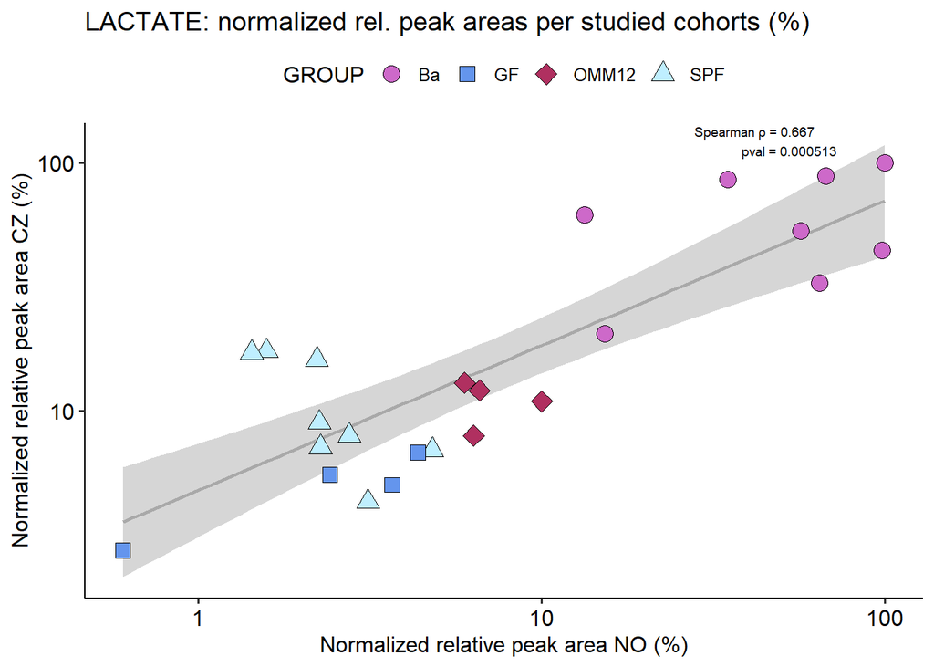

```r
ggplot(lactate, aes(x = NO, y = CZ)) +
  geom_smooth(method = "lm", linewidth = 0.8, color = "darkgrey") +
  geom_point(aes(shape = GROUP, fill = GROUP),
             color = "black",      # border colour for all points
             size = 4,
             stroke = 0.5) +       # border thickness
  theme_pubr() +
  annotate("text",
           x = Inf, y = Inf,
           label = paste0("Spearman ρ = ", lac_rho, "\npval = ", lac_pval),
           hjust = 1.9, vjust = 1.1,
           size = 2.5) +
  scale_x_log10(breaks = c(0.1, 1, 10, 100),
                labels = c("0.1", "1", "10", "100")) +
  scale_y_log10(breaks = c(0.1, 1, 10, 100),
                labels = c("0.1", "1", "10", "100")) +
  scale_shape_manual(values = c("Ba" = 21, "GF" = 22, "OMM12" = 23, "SPF" = 24)) +
  scale_fill_manual(values = c(Ba = "orchid3", GF = "cornflowerblue", OMM12 = "maroon", SPF = "lightblue1")) +
  labs(
    title = "LACTATE: normalized rel. peak areas per studied cohorts (%)",
    x = "Normalized relative peak area NO (%)",
    y = "Normalized relative peak area CZ (%)")
```

Assign it to the variable Lactate_spearman and save it as a .png

```r
Lactate_spearman <-ggplot(lactate, aes(x = NO, y = CZ)) +
  geom_smooth(method = "lm", linewidth = 0.8, color = "darkgrey") +
  geom_point(aes(shape = GROUP, fill = GROUP),
             color = "black",      # border colour for all points
             size = 3,
             stroke = 0.5) +       # border thickness
  theme_pubr() +
  annotate("text",
           x = Inf, y = Inf,
           label = paste0("Spearman ρ = ", lac_rho, "\npval = ", lac_pval),
           hjust = 1.9, vjust = 1.1,
           size = 3.5) +
  scale_x_log10(breaks = c(0.1, 1, 10, 100),
                labels = c("0.1", "1", "10", "100")) +
  scale_y_log10(breaks = c(0.1, 1, 10, 100),
                labels = c("0.1", "1", "10", "100")) +
  scale_shape_manual(values = c("Ba" = 21, "GF" = 22, "OMM12" = 23, "SPF" = 24)) +
  scale_fill_manual(values = c(Ba = "orchid3", GF = "cornflowerblue", OMM12 = "maroon", SPF = "lightblue1")) +
  labs(
    title = "LACTATE",
    x = "Normalized relative peak area NO (%)",
    y = "Normalized relative peak area CZ (%)")+
    theme(
    plot.title   = element_text(size = 12, face = "bold"),
    axis.title.x = element_text(size = 10),
    axis.title.y = element_text(size = 10),
    legend.text =  element_text(size = 12)
  )
ggsave("Lactate_spearman_correlation.png",
       plot = Lactate_spearman,
       width = 10, height = 10, dpi = 300)
```

A C E T A T E

Import the dataset and exclude blanks

```r
acetate <- read_excel("NORWAY_QUANTIFICATION.xlsx", sheet = "NEW_ACETATE") %>%
  as.data.frame() %>%
  mutate(`MEDIAN_REL_AREA_NORMALIZED` = as.numeric(`MEDIAN_REL_AREA_NORMALIZED`)) %>%
  filter(COHORT != "Blank")  # Remove rows where COHORT is "Blank"
```

Filter only valued for replicate1 in the column “Replicate” and exclude samples CV5 and CV6

```r
acetate <- acetate %>%
  filter(REPLICATE == "Rep1", !TYPE %in% c("CV5", "CV6"))
```

Create new column “Group”

```r
acetate <- acetate %>%
  mutate(GROUP = sub("_.*", "", COHORT))
```

Reshape the data matrix and extract only values for plotting

```r
acetate <- acetate %>%
  select(TYPE, GROUP, COUNTRY, `MEDIAN_REL_AREA_NORMALIZED`) %>%
  pivot_wider(
    names_from = COUNTRY,
    values_from = `MEDIAN_REL_AREA_NORMALIZED`
  )

acetate <- acetate %>%
  mutate(
    CZ = as.numeric(CZ),
    NO = as.numeric(NO)
  )
```

Add Spearman Correlation test

```r
ac_res <- cor.test(acetate$NO, acetate$CZ, method = "spearman")
ac_rho <- round(ac_res$estimate, 3)
ac_pval <- signif(ac_res$p.value, 3)
```

Check the correlation plot

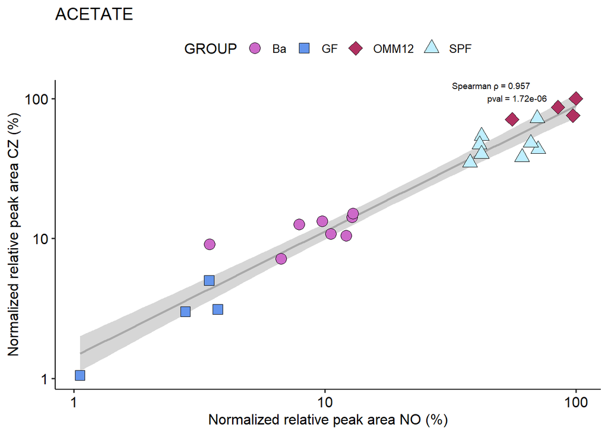

```r
ggplot(acetate, aes(x = NO, y = CZ)) +
  geom_smooth(method = "lm", linewidth = 0.8, color = "darkgrey") +
  geom_point(aes(shape = GROUP, fill = GROUP),
             color = "black",      # border colour for all points
             size = 4,
             stroke = 0.5) +       # border thickness
  #geom_text_repel(
    #data = subset(acetate, GROUP == "SPF"),
    #aes(label = TYPE),
    #size = 3,
    #max.overlaps = Inf,
    #box.padding = 0.6
  #) +
  theme_pubr() +
  annotate("text",
           x = Inf, y = Inf,
           label = paste0("Spearman ρ = ", ac_rho, "\npval = ", ac_pval),
           hjust = 1.9, vjust = 1.1,
           size = 2.5) +
  scale_x_log10(breaks = c(0.1, 1, 10, 100),
                labels = c("0.1", "1", "10", "100")) +
  scale_y_log10(breaks = c(0.1, 1, 10, 100),
                labels = c("0.1", "1", "10", "100")) +
  scale_shape_manual(values = c("Ba" = 21, "GF" = 22, "OMM12" = 23, "SPF" = 24)) +
  scale_fill_manual(values = c(Ba = "orchid3", GF = "cornflowerblue", OMM12 = "maroon", SPF = "lightblue1")) +
  labs(
    title = "ACETATE",
    x = "Normalized relative peak area NO (%)",
    y = "Normalized relative peak area CZ (%)")
```

Assign it to the variable Acetate_spearman and save it as a figure in .png

```r
Acetate_spearman<- ggplot(acetate, aes(x = NO, y = CZ)) +
  geom_smooth(method = "lm", linewidth = 0.8, color = "darkgrey") +
  geom_point(aes(shape = GROUP, fill = GROUP),
             color = "black",      # border colour for all points
             size = 3,
             stroke = 0.5) +       # border thickness
  #geom_text_repel(
    #data = subset(acetate, GROUP == "SPF"),
    #aes(label = TYPE),
    #size = 3,
    #max.overlaps = Inf,
    #box.padding = 0.6
  #) +
  theme_pubr() +
  annotate("text",
           x = Inf, y = Inf,
           label = paste0("Spearman ρ = ", ac_rho, "\npval = ", ac_pval),
           hjust = 1.9, vjust = 1.1,
           size = 3.5) +
  scale_x_log10(breaks = c(0.1, 1, 10, 100),
                labels = c("0.1", "1", "10", "100")) +
  scale_y_log10(breaks = c(0.1, 1, 10, 100),
                labels = c("0.1", "1", "10", "100")) +
  scale_shape_manual(values = c("Ba" = 21, "GF" = 22, "OMM12" = 23, "SPF" = 24)) +
  scale_fill_manual(values = c(Ba = "orchid3", GF = "cornflowerblue", OMM12 = "maroon", SPF = "lightblue1")) +
  labs(
    title = "ACETATE",
    x = "Normalized relative peak area NO (%)",
    y = "Normalized relative peak area CZ (%)")+
    theme(
    plot.title   = element_text(size = 12, face = "bold"),
    axis.title.x = element_text(size = 10),
    axis.title.y = element_text(size = 10),
    legend.text =  element_text(size = 12)
  )
ggsave("Acetate_spearman_correlation.png",
       plot = Acetate_spearman,
       width = 10, height = 10, dpi = 300)
```

P R O P I O N A T E

Import the dataset and exclude blanks

```r
propionate <- read_excel("NORWAY_QUANTIFICATION.xlsx", sheet = "NEW_PROPIONATE") %>%
  as.data.frame() %>%
  mutate(`MEDIAN_REL_AREA_NORMALIZED` = as.numeric(`MEDIAN_REL_AREA_NORMALIZED`)) %>%
  filter(COHORT != "Blank")  # Remove rows where COHORT is "Blank"
```

Filter only valued for replicate1 in the column “Replicate” and exclude samples CV5 and CV6

```r
propionate <- propionate %>%
  filter(REPLICATE == "Rep1", !TYPE %in% c("CV5", "CV6"))
```

Create new column “Group”

```r
propionate <- propionate %>%
  mutate(GROUP = sub("_.*", "", COHORT))
```

Reshape the data matrix and extract only values for plotting

```r
propionate <- propionate %>%
  select(TYPE, GROUP, COUNTRY, `MEDIAN_REL_AREA_NORMALIZED`) %>%
  pivot_wider(
    names_from = COUNTRY,
    values_from = `MEDIAN_REL_AREA_NORMALIZED`
  )

propionate <- propionate %>%
  mutate(
    CZ = as.numeric(CZ),
    NO = as.numeric(NO)
  )
```

Add Spearman Correlation test

```r
pro_res <- cor.test(propionate$NO, propionate$CZ, method = "spearman")
pro_rho <- round(pro_res$estimate, 3)
pro_pval <- signif(pro_res$p.value, 3)
```

Check the correlation plot

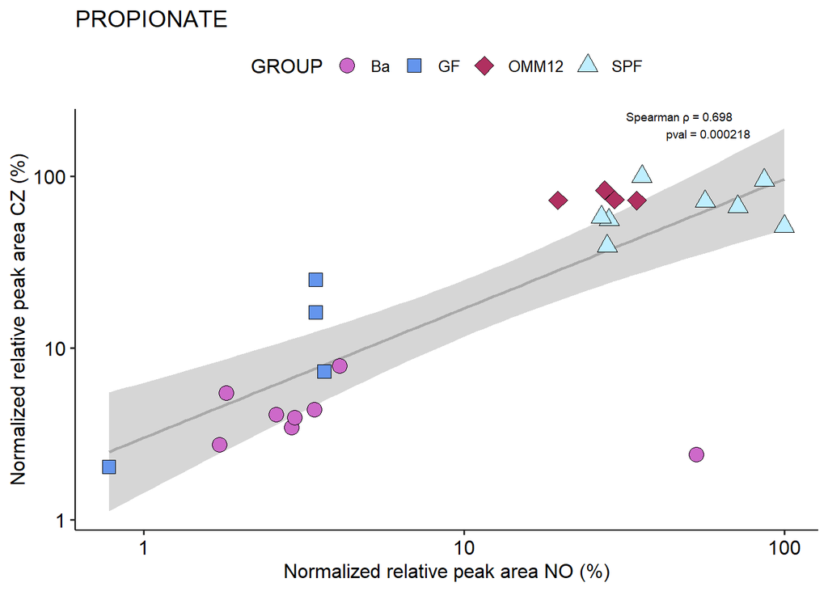

```r
ggplot(propionate, aes(x = NO, y = CZ)) +
  geom_smooth(method = "lm", linewidth = 0.8, color = "darkgrey") +
  geom_point(aes(shape = GROUP, fill = GROUP),
             color = "black",      # border colour for all points
             size = 4,
             stroke = 0.5) +       # border thickness
  theme_pubr() +
  annotate("text",
           x = Inf, y = Inf,
           label = paste0("Spearman ρ = ", pro_rho, "\npval = ", pro_pval),
           hjust = 1.8, vjust = 1.1,
           size = 2.5) +
  scale_x_log10(breaks = c(0.1, 1, 10, 100),
                labels = c("0.1", "1", "10", "100")) +
  scale_y_log10(breaks = c(0.1, 1, 10, 100),
                labels = c("0.1", "1", "10", "100")) +
  scale_shape_manual(values = c("Ba" = 21, "GF" = 22, "OMM12" = 23, "SPF" = 24)) +
  scale_fill_manual(values = c(Ba = "orchid3", GF = "cornflowerblue", OMM12 = "maroon", SPF = "lightblue1")) +
  labs(
    title = "PROPIONATE",
    x = "Normalized relative peak area NO (%)",
    y = "Normalized relative peak area CZ (%)")
```

Assign it to the variable Propionate_spearman and save it as a .png

```r
Propionate_spearman <- ggplot(propionate, aes(x = NO, y = CZ)) +
  geom_smooth(method = "lm", linewidth = 0.8, color = "darkgrey") +
  geom_point(aes(shape = GROUP, fill = GROUP),
             color = "black",      # border colour for all points
             size = 3,
             stroke = 0.5) +       # border thickness
  theme_pubr() +
  annotate("text",
           x = Inf, y = Inf,
           label = paste0("Spearman ρ = ", pro_rho, "\npval = ", pro_pval),
           hjust = 1.9, vjust = 1.1,
           size = 3.5) +
  scale_x_log10(breaks = c(0.1, 1, 10, 100),
                labels = c("0.1", "1", "10", "100")) +
  scale_y_log10(breaks = c(0.1, 1, 10, 100),
                labels = c("0.1", "1", "10", "100")) +
  scale_shape_manual(values = c("Ba" = 21, "GF" = 22, "OMM12" = 23, "SPF" = 24)) +
  scale_fill_manual(values = c(Ba = "orchid3", GF = "cornflowerblue", OMM12 = "maroon", SPF = "lightblue1")) +
  labs(
    title = "PROPIONATE",
    x = "Normalized relative peak area NO (%)",
    y = "Normalized relative peak area CZ (%)")+
    theme(
    plot.title   = element_text(size = 12, face = "bold"),
    axis.title.x = element_text(size = 10),
    axis.title.y = element_text(size = 10)
  )
ggsave("Propionate_spearman_correlation.png",
       plot = Propionate_spearman,
       width = 10, height = 10, dpi = 300)
```

B U T Y R A T E

Import the dataset and exclude blanks

```r
butyrate <- read_excel("NORWAY_QUANTIFICATION.xlsx", sheet = "NEW_BUTYRATE") %>%
  as.data.frame() %>%
  mutate(`MEDIAN_REL_AREA_NORMALIZED` = as.numeric(`MEDIAN_REL_AREA_NORMALIZED`)) %>%
  filter(COHORT != "Blank")  # Remove rows where COHORT is "Blank"
```

Filter only valued for replicate1 in the column “Replicate” and exclude samples CV5 and CV6

```r
butyrate <- butyrate %>%
  filter(REPLICATE == "Rep1", !TYPE %in% c("CV5", "CV6"))
```

Create new column “Group”

```r
butyrate <- butyrate %>%
  mutate(GROUP = sub("_.*", "", COHORT))
```

Reshape the data matrix and extract only values for plotting

```r
butyrate <- butyrate %>%
  select(TYPE, GROUP, COUNTRY, `MEDIAN_REL_AREA_NORMALIZED`) %>%
  pivot_wider(
    names_from = COUNTRY,
    values_from = `MEDIAN_REL_AREA_NORMALIZED`
  )

butyrate <- butyrate %>%
  mutate(
    CZ = as.numeric(CZ),
    NO = as.numeric(NO)
  )
```

Add Spearman Correlation test

```r
but_res <- cor.test(butyrate$NO, butyrate$CZ, method = "spearman")
but_rho <- round(but_res$estimate, 3)
but_pval <- signif(but_res$p.value, 3)
```

Check the correlation plot

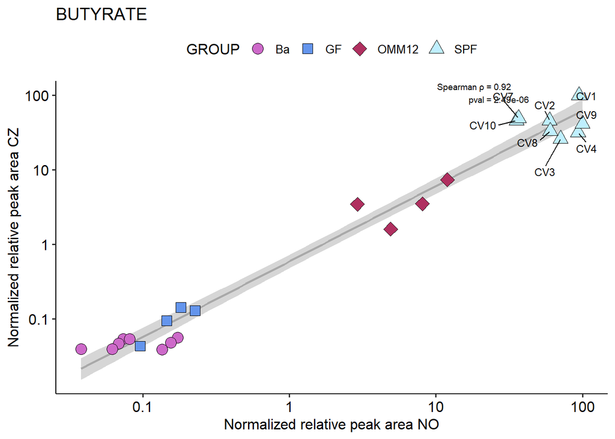

```r
ggplot(butyrate, aes(x = NO, y = CZ)) +
  geom_smooth(method = "lm", linewidth = 0.8, color = "darkgrey") +
  geom_point(aes(shape = GROUP, fill = GROUP),
             color = "black",      # border colour for all points
             size = 4,
             stroke = 0.5) +       # border thickness
  geom_text_repel(
    data = subset(butyrate, GROUP == "SPF"),
    aes(label = TYPE),
    size = 3,
    max.overlaps = Inf,
    box.padding = 0.6
  ) +
  theme_pubr() +
  annotate("text",
           x = Inf, y = Inf,
           label = paste0("Spearman ρ = ", but_rho, "\npval = ", but_pval),
           hjust = 2.3, vjust = 1.1,
           size = 2.5) +
  scale_x_log10(breaks = c(0.1, 1, 10, 100),
                labels = c("0.1", "1", "10", "100")) +
  scale_y_log10(breaks = c(0.1, 1, 10, 100),
                labels = c("0.1", "1", "10", "100")) +
  scale_shape_manual(values = c("Ba" = 21, "GF" = 22, "OMM12" = 23, "SPF" = 24)) +
  scale_fill_manual(values = c(Ba = "orchid3", GF = "cornflowerblue", OMM12 = "maroon", SPF = "lightblue1")) +
  labs(
    title = "BUTYRATE",
    x = "Normalized relative peak area NO",
    y = "Normalized relative peak area CZ")
```

Assign it to the variable Butyrate_spearman and save it as a .png

```r
Butyrate_spearman <- ggplot(butyrate, aes(x = NO, y = CZ)) +
  geom_smooth(method = "lm", linewidth = 0.8, color = "darkgrey") +
  geom_point(aes(shape = GROUP, fill = GROUP),
             color = "black",      # border colour for all points
             size = 3,
             stroke = 0.5) +       # border thickness
  #geom_text_repel(
    #data = subset(butyrate, GROUP == "SPF"),
    #aes(label = TYPE),
    #size = 3,
    #max.overlaps = Inf,
    #box.padding = 0.6
  #) +
  theme_pubr() +
  annotate("text",
           x = Inf, y = Inf,
           label = paste0("Spearman ρ = ", but_rho, "\npval = ", but_pval),
           hjust = 1.9, vjust = 1.1,
           size = 3.5) +
  scale_x_log10(breaks = c(0.1, 1, 10, 100),
                labels = c("0.1", "1", "10", "100")) +
  scale_y_log10(breaks = c(0.1, 1, 10, 100),
                labels = c("0.1", "1", "10", "100")) +
  scale_shape_manual(values = c("Ba" = 21, "GF" = 22, "OMM12" = 23, "SPF" = 24)) +
  scale_fill_manual(values = c(Ba = "orchid3", GF = "cornflowerblue", OMM12 = "maroon", SPF = "lightblue1")) +
  labs(
    title = "BUTYRATE",
    x = "Normalized relative peak area NO (%)",
    y = "Normalized relative peak area CZ (%)")+
    theme(
    plot.title   = element_text(size = 12, face = "bold"),
    axis.title.x = element_text(size = 10),
    axis.title.y = element_text(size = 10),
    legend.text =  element_text(size = 12)
  )
ggsave("Butyrate_spearman_correlation.png",
       plot = Butyrate_spearman,
       width = 10, height = 10, dpi = 300)
```

I S O B U T Y R A T E

Import the dataset and exclude blanks

```r
isobutyrate <- read_excel("NORWAY_QUANTIFICATION.xlsx", sheet = "NEW_ISOBUTYRATE") %>%
  as.data.frame() %>%
  mutate(`MEDIAN_REL_AREA_NORMALIZED` = as.numeric(`MEDIAN_REL_AREA_NORMALIZED`)) %>%
  filter(COHORT != "Blank")  # Remove rows where COHORT is "Blank"
```

Filter only valued for replicate1 in the column “Replicate” and exclude samples CV5 and CV6

```r
isobutyrate <- isobutyrate %>%
  filter(REPLICATE == "Rep1", !TYPE %in% c("CV5", "CV6"))
```

Create new column “Group”

```r
isobutyrate <- isobutyrate %>%
  mutate(GROUP = sub("_.*", "", COHORT))
```

Reshape the data matrix and extract only values for plotting

```r
isobutyrate <- isobutyrate %>%
  select(TYPE, GROUP, COUNTRY, `MEDIAN_REL_AREA_NORMALIZED`) %>%
  pivot_wider(
    names_from = COUNTRY,
    values_from = `MEDIAN_REL_AREA_NORMALIZED`
  )

isobutyrate <- isobutyrate %>%
  mutate(
    CZ = as.numeric(CZ),
    NO = as.numeric(NO)
  )
```

Add Spearman Correlation test

```r
isobut_res <- cor.test(isobutyrate$NO, isobutyrate$CZ, method = "spearman")
isobut_rho <- round(isobut_res$estimate, 3)
isobut_pval <- signif(isobut_res$p.value, 3)
```

Check the correlation plot

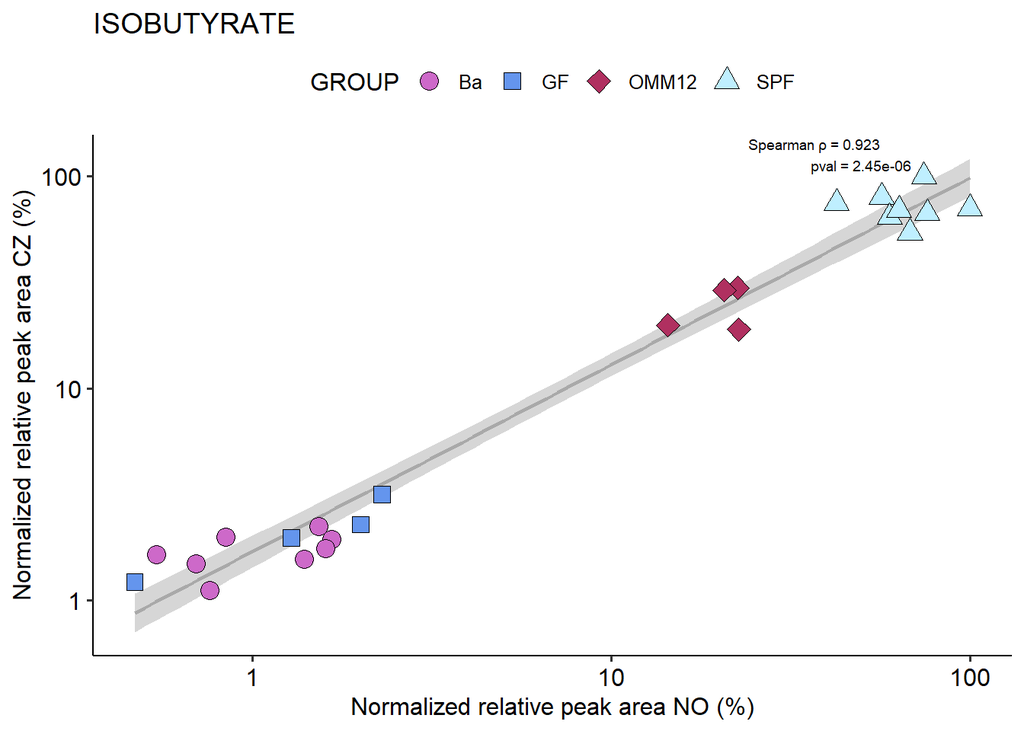

```r
ggplot(isobutyrate, aes(x = NO, y = CZ)) +
  geom_smooth(method = "lm", linewidth = 0.8, color = "darkgrey") +
  geom_point(aes(shape = GROUP, fill = GROUP),
             color = "black",      # border colour for all points
             size = 4,
             stroke = 0.5) +       # border thickness
  theme_pubr() +
  annotate("text",
           x = Inf, y = Inf,
           label = paste0("Spearman ρ = ", isobut_rho, "\npval = ", isobut_pval),
           hjust = 2, vjust = 1.1,
           size = 2.5) +
  scale_x_log10(breaks = c(0.1, 1, 10, 100),
                labels = c("0.1", "1", "10", "100")) +
  scale_y_log10(breaks = c(0.1, 1, 10, 100),
                labels = c("0.1", "1", "10", "100")) +
  scale_shape_manual(values = c("Ba" = 21, "GF" = 22, "OMM12" = 23, "SPF" = 24)) +
  scale_fill_manual(values = c(Ba = "orchid3", GF = "cornflowerblue", OMM12 = "maroon", SPF = "lightblue1")) +
  labs(
    title = "ISOBUTYRATE",
    x = "Normalized relative peak area NO (%)",
    y = "Normalized relative peak area CZ (%)")
```

Assign it to the variable Isobutyrate_spearman and save it as a .png

```r
Isobutyrate_spearman <- ggplot(isobutyrate, aes(x = NO, y = CZ)) +
  geom_smooth(method = "lm", linewidth = 0.8, color = "darkgrey") +
  geom_point(aes(shape = GROUP, fill = GROUP),
             color = "black",      # border colour for all points
             size = 3,
             stroke = 0.5) +       # border thickness
  theme_pubr() +
  annotate("text",
           x = Inf, y = Inf,
           label = paste0("Spearman ρ = ", isobut_rho, "\npval = ", isobut_pval),
           hjust = 1.9, vjust = 1.1,
           size = 3.5) +
  scale_x_log10(breaks = c(0.1, 1, 10, 100),
                labels = c("0.1", "1", "10", "100")) +
  scale_y_log10(breaks = c(0.1, 1, 10, 100),
                labels = c("0.1", "1", "10", "100")) +
  scale_shape_manual(values = c("Ba" = 21, "GF" = 22, "OMM12" = 23, "SPF" = 24)) +
  scale_fill_manual(values = c(Ba = "orchid3", GF = "cornflowerblue", OMM12 = "maroon", SPF = "lightblue1")) +
  labs(
    title = "ISOBUTYRATE",
    x = "Normalized relative peak area NO (%)",
    y = "Normalized relative peak area CZ (%)") +
  theme(
    plot.title   = element_text(size = 12, face = "bold"),
    axis.title.x = element_text(size = 10),
    axis.title.y = element_text(size = 10)
  )

ggsave("Isobutyrate_spearman_correlation.png",
       plot = Isobutyrate_spearman,
       width = 10, height = 10, dpi = 300)
```

V A L E R A T E

Import the dataset and exclude blanks

```r
valerate <- read_excel("NORWAY_QUANTIFICATION.xlsx", sheet = "NEW_VALERATE") %>%
  as.data.frame() %>%
  mutate(`MEDIAN_REL_AREA_NORMALIZED` = as.numeric(`MEDIAN_REL_AREA_NORMALIZED`)) %>%
  filter(COHORT != "Blank")  # Remove rows where COHORT is "Blank"
```

Filter only valued for replicate1 in the column “Replicate” and exclude samples CV5 and CV6

```r
valerate <- valerate %>%
  filter(REPLICATE == "Rep1", !TYPE %in% c("CV5", "CV6"))
```

Create new column “Group”

```r
valerate <- valerate %>%
  mutate(GROUP = sub("_.*", "", COHORT))
```

Reshape the data matrix and extract only values for plotting

```r
valerate <- valerate %>%
  select(TYPE, GROUP, COUNTRY, `MEDIAN_REL_AREA_NORMALIZED`) %>%
  pivot_wider(
    names_from = COUNTRY,
    values_from = `MEDIAN_REL_AREA_NORMALIZED`
  )

valerate <- valerate %>%
  mutate(
    CZ = as.numeric(CZ),
    NO = as.numeric(NO)
  )
```

Add Spearman Correlation test

```r
val_res <- cor.test(valerate$NO, valerate$CZ, method = "spearman")
val_rho <- round(val_res$estimate, 3)
val_pval <- signif(val_res$p.value, 3)
```

Check the correlation plot

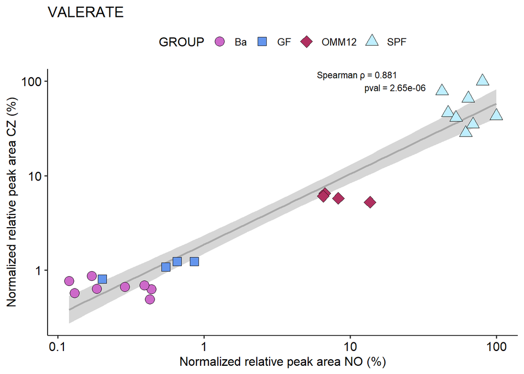

```r
ggplot(valerate, aes(x = NO, y = CZ)) +
  geom_smooth(method = "lm", linewidth = 0.8, color = "darkgrey") +
  geom_point(aes(shape = GROUP, fill = GROUP),
             color = "black",      # border colour for all points
             size = 4,
             stroke = 0.5) +       # border thickness
  theme_pubr() +
  annotate("text",
           x = Inf, y = Inf,
           label = paste0("Spearman ρ = ", val_rho, "\npval = ", val_pval),
           hjust = 2.5, vjust = 1.1,
           size = 3) +
  scale_x_log10(breaks = c(0.1, 1, 10, 100),
                 labels = c("0.1", "1", "10", "100")) +
  scale_y_log10(breaks = c(0.1, 1, 10, 100),
                labels = c("0.1", "1", "10", "100")) +
  scale_shape_manual(values = c("Ba" = 21, "GF" = 22, "OMM12" = 23, "SPF" = 24)) +
  scale_fill_manual(values = c(Ba = "orchid3", GF = "cornflowerblue", OMM12 = "maroon", SPF = "lightblue1")) +
  labs(
    title = "VALERATE",
    x = "Normalized relative peak area NO (%)",
    y = "Normalized relative peak area CZ (%)")
```

Assign it to the variable Valerate_spearman and save it as a .png

```r
Valerate_spearman <- ggplot(valerate, aes(x = NO, y = CZ)) +
  geom_smooth(method = "lm", linewidth = 0.8, color = "darkgrey") +
  geom_point(aes(shape = GROUP, fill = GROUP),
             color = "black",      # border colour for all points
             size = 3,
             stroke = 0.5) +       # border thickness
  theme_pubr() +
  annotate("text",
           x = Inf, y = Inf,
           label = paste0("Spearman ρ = ", val_rho, "\npval = ", val_pval),
           hjust = 1.9, vjust = 1.1,
           size = 3.5) +
  scale_x_log10(breaks = c(0.1, 1, 10, 100),
                 labels = c("0.1", "1", "10", "100")) +
  scale_y_log10(breaks = c(0.1, 1, 10, 100),
                labels = c("0.1", "1", "10", "100")) +
  scale_shape_manual(values = c("Ba" = 21, "GF" = 22, "OMM12" = 23, "SPF" = 24)) +
  scale_fill_manual(values = c(Ba = "orchid3", GF = "cornflowerblue", OMM12 = "maroon", SPF = "lightblue1")) +
  labs(
    title = "VALERATE",
    x = "Normalized relative peak area NO (%)",
    y = "Normalized relative peak area CZ (%)")+
    theme(
    plot.title   = element_text(size = 12, face = "bold"),
    axis.title.x = element_text(size = 10),
    axis.title.y = element_text(size = 10),
    legend.text =  element_text(size = 12)
  )
ggsave("Valerate_spearman_correlation.png",
       plot = Valerate_spearman,
       width = 10, height = 10, dpi = 300)
```

I S O V A L E R A T E

Import the dataset and exclude blanks

```r
isovalerate <- read_excel("NORWAY_QUANTIFICATION.xlsx", sheet = "NEW_ISOVALERATE") %>%
  as.data.frame() %>%
  mutate(`MEDIAN_REL_AREA_NORMALIZED` = as.numeric(`MEDIAN_REL_AREA_NORMALIZED`)) %>%
  filter(COHORT != "Blank")  # Remove rows where COHORT is "Blank"
```

Filter only valued for replicate1 in the column “Replicate” and exclude samples CV5 and CV6

```r
isovalerate <- isovalerate %>%
  filter(REPLICATE == "Rep1", !TYPE %in% c("CV5", "CV6"))
```

Create new column “Group”

```r
isovalerate <- isovalerate %>%
  mutate(GROUP = sub("_.*", "", COHORT))
```

Reshape the data matrix and extract only values for plotting

```r
isovalerate <- isovalerate %>%
  select(TYPE, GROUP, COUNTRY, `MEDIAN_REL_AREA_NORMALIZED`) %>%
  pivot_wider(
    names_from = COUNTRY,
    values_from = `MEDIAN_REL_AREA_NORMALIZED`
  )

isovalerate <- isovalerate %>%
  mutate(
    CZ = as.numeric(CZ),
    NO = as.numeric(NO)
  )
```

Add Spearman Correlation test

```r
isoval_res <- cor.test(isovalerate$NO, isovalerate$CZ, method = "spearman")
isoval_rho <- round(isoval_res$estimate, 3)
isoval_pval <- signif(isoval_res$p.value, 3)
```

Check the correlation plot

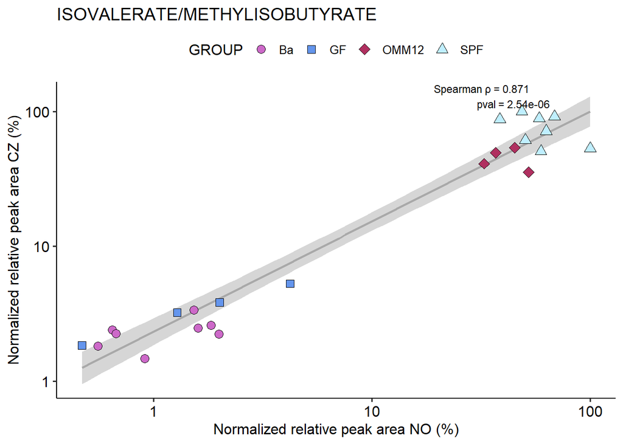

```r
ggplot(isovalerate, aes(x = NO, y = CZ)) +
  geom_smooth(method = "lm", linewidth = 0.8, color = "darkgrey") +
  geom_point(aes(shape = GROUP, fill = GROUP),
             color = "black",      # border colour for all points
             size = 3,
             stroke = 0.5) +       # border thickness
  theme_pubr() +
  annotate("text",
           x = Inf, y = Inf,
           label = paste0("Spearman ρ = ", isoval_rho, "\npval = ", isoval_pval),
           hjust = 1.9, vjust = 1.1,
           size = 3) +
  scale_x_log10(breaks = c(0.1, 1, 10, 100),
                labels = c("0.1", "1", "10", "100")) +
  scale_y_log10(breaks = c(0.1, 1, 10, 100),
                labels = c("0.1", "1", "10", "100")) +
  scale_shape_manual(values = c("Ba" = 21, "GF" = 22, "OMM12" = 23, "SPF" = 24)) +
  scale_fill_manual(values = c(Ba = "orchid3", GF = "cornflowerblue", OMM12 = "maroon", SPF = "lightblue1")) +
  labs(
    title = "ISOVALERATE/METHYLISOBUTYRATE",
    x = "Normalized relative peak area NO (%)",
    y = "Normalized relative peak area CZ (%)")
```

Assign it to the variable Isovalerate_spearman and save it as a .png

```r
Isovalerate_spearman<- ggplot(isovalerate, aes(x = NO, y = CZ)) +
  geom_smooth(method = "lm", linewidth = 0.8, color = "darkgrey") +
  geom_point(aes(shape = GROUP, fill = GROUP),
             color = "black",      # border colour for all points
             size = 3,
             stroke = 0.5) +       # border thickness
  theme_pubr() +
  annotate("text",
           x = Inf, y = Inf,
           label = paste0("Spearman ρ = ", isoval_rho, "\npval = ", isoval_pval),
           hjust = 1.9, vjust = 1.1,
           size = 3.5) +
  scale_x_log10(breaks = c(0.1, 1, 10, 100),
                labels = c("0.1", "1", "10", "100")) +
  scale_y_log10(breaks = c(0.1, 1, 10, 100),
                labels = c("0.1", "1", "10", "100")) +
  scale_shape_manual(values = c("Ba" = 21, "GF" = 22, "OMM12" = 23, "SPF" = 24)) +
  scale_fill_manual(values = c(Ba = "orchid3", GF = "cornflowerblue", OMM12 = "maroon", SPF = "lightblue1")) +
  labs(
    title = "ISOVALERATE/METHYLISOBUTYRATE",
    x = "Normalized relative peak area NO (%)",
    y = "Normalized relative peak area CZ (%)")+
    theme(
    plot.title   = element_text(size = 12, face = "bold"),
    axis.title.x = element_text(size = 10),
    axis.title.y = element_text(size = 10),
    legend.text =  element_text(size = 12)
  )
ggsave("Isovalerate_spearman_correlation.png",
       plot = Isovalerate_spearman,
       width = 10, height = 10, dpi = 300)
```

P I V A L A T E

Import the dataset and exclude blanks

```r
pivalate <- read_excel("NORWAY_QUANTIFICATION.xlsx", sheet = "NEW_PIVALATE") %>%
  as.data.frame() %>%
  mutate(`MEDIAN_REL_AREA_NORMALIZED` = as.numeric(`MEDIAN_REL_AREA_NORMALIZED`)) %>%
  filter(COHORT != "Blank")  # Remove rows where COHORT is "Blank"
```

Filter only valued for replicate1 in the column “Replicate” and exclude samples CV5 and CV6

```r
pivalate <- pivalate %>%
  filter(REPLICATE == "Rep1", !TYPE %in% c("CV5", "CV6"))
```

Create new column “Group”

```r
pivalate <- pivalate %>%
  mutate(GROUP = sub("_.*", "", COHORT))
```

Reshape the data matrix and extract only values for plotting

```r
pivalate <- pivalate %>%
  select(TYPE, GROUP, COUNTRY, `MEDIAN_REL_AREA_NORMALIZED`) %>%
  pivot_wider(
    names_from = COUNTRY,
    values_from = `MEDIAN_REL_AREA_NORMALIZED`
  )

pivalate <- pivalate %>%
  mutate(
    CZ = as.numeric(CZ),
    NO = as.numeric(NO)
  )
```

Add Spearman Correlation test

```r
pival_res <- cor.test(pivalate$NO, pivalate$CZ, method = "spearman")
pival_rho <- round(pival_res$estimate, 3)
pival_pval <- signif(pival_res$p.value, 3)
```

Check the correlation plot

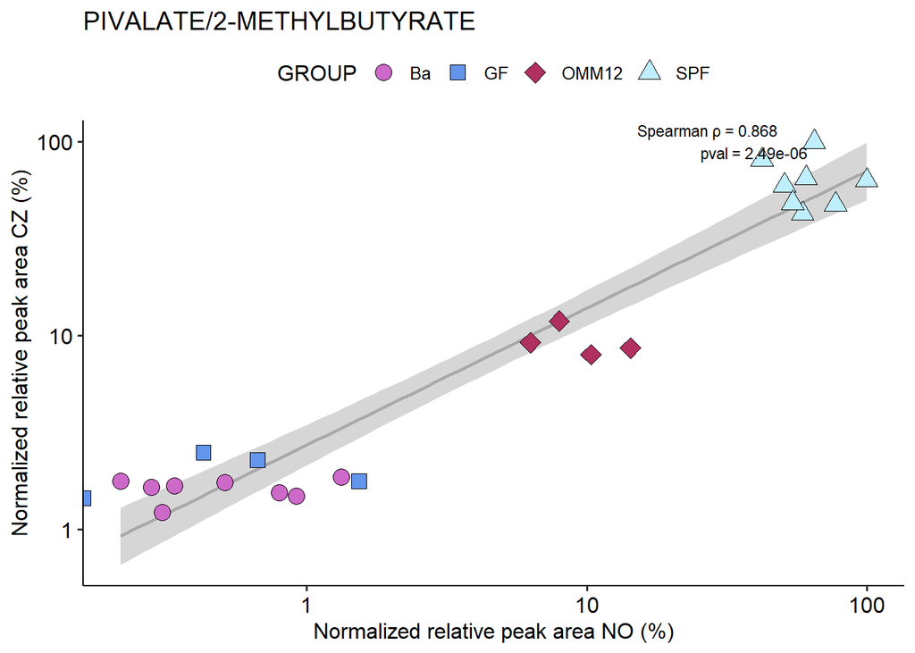

```r
ggplot(pivalate, aes(x = NO, y = CZ)) +
  geom_smooth(method = "lm", linewidth = 0.8, color = "darkgrey") +
  geom_point(aes(shape = GROUP, fill = GROUP),
             color = "black",      # border colour for all points
             size = 4,
             stroke = 0.5) +       # border thickness
  theme_pubr() +
  annotate("text",
           x = Inf, y = Inf,
           label = paste0("Spearman ρ = ", pival_rho, "\npval = ", pival_pval),
          hjust = 1.9, vjust = 1.1,
           size = 3) +
  scale_x_log10(breaks = c(0.001, 1, 10, 100),
                labels = c("0.001", "1", "10", "100")) +
  scale_y_log10(breaks = c(0.001, 1, 10, 100),
                labels = c("0.001", "1", "10", "100")) +
  scale_shape_manual(values = c("Ba" = 21, "GF" = 22, "OMM12" = 23, "SPF" = 24)) +
  scale_fill_manual(values = c(Ba = "orchid3", GF = "cornflowerblue", OMM12 = "maroon", SPF = "lightblue1")) +
  labs(
    title = "PIVALATE/2-METHYLBUTYRATE",
    x = "Normalized relative peak area NO (%)",
    y = "Normalized relative peak area CZ (%)")
```

Assign it to the variable Pivalate_spearman and save it as a .png

```r
Pivalate_spearman <-ggplot(pivalate, aes(x = NO, y = CZ)) +
  geom_smooth(method = "lm", linewidth = 0.8, color = "darkgrey") +
  geom_point(aes(shape = GROUP, fill = GROUP),
             color = "black",      # border colour for all points
             size = 3,
             stroke = 0.5) +       # border thickness
  theme_pubr() +
  annotate("text",
           x = Inf, y = Inf,
           label = paste0("Spearman ρ = ", pival_rho, "\npval = ", pival_pval),
           hjust = 1.9, vjust = 1.1,
           size = 3.5) +
  scale_x_log10(breaks = c(0.001, 1, 10, 100),
                labels = c("0.001", "1", "10", "100")) +
  scale_y_log10(breaks = c(0.001, 1, 10, 100),
                labels = c("0.001", "1", "10", "100")) +
  scale_shape_manual(values = c("Ba" = 21, "GF" = 22, "OMM12" = 23, "SPF" = 24)) +
  scale_fill_manual(values = c(Ba = "orchid3", GF = "cornflowerblue", OMM12 = "maroon", SPF = "lightblue1")) +
  labs(
    title = "PIVALATE/2-METHYLBUTYRATE",
    x = "Normalized relative peak area NO (%)",
    y = "Normalized relative peak area CZ (%)")+
    theme(
    plot.title   = element_text(size = 12, face = "bold"),
    axis.title.x = element_text(size = 10),
    axis.title.y = element_text(size = 10),
    legend.text =  element_text(size = 12)
  )
ggsave("Pivalate_spearman_correlation.png",
       plot = Pivalate_spearman,
       width = 10, height = 10, dpi = 300)
```

C I T R A T E

Import the dataset and exclude blanks

```r
citrate <- read_excel("NORWAY_QUANTIFICATION.xlsx", sheet = "NEW_CITRATE") %>%
  as.data.frame() %>%
  mutate(`MEDIAN_REL_AREA_NORMALIZED` = as.numeric(`MEDIAN_REL_AREA_NORMALIZED`)) %>%
  filter(COHORT != "Blank")  # Remove rows where COHORT is "Blank"
```

Filter only valued for replicate1 in the column “Replicate” and exclude samples CV5 and CV6

```r
citrate <- citrate %>%
  filter(REPLICATE == "Rep1", !TYPE %in% c("CV5", "CV6"))
```

Create new column “Group”

```r
citrate <- citrate %>%
  mutate(GROUP = sub("_.*", "", COHORT))
```

Reshape the data matrix and extract only values for plotting

```r
citrate <- citrate %>%
  select(TYPE, GROUP, COUNTRY, `MEDIAN_REL_AREA_NORMALIZED`) %>%
  pivot_wider(
    names_from = COUNTRY,
    values_from = `MEDIAN_REL_AREA_NORMALIZED`
  )

citrate <- citrate %>%
  mutate(
    CZ = as.numeric(CZ),
    NO = as.numeric(NO)
  )
```

Add Spearman Correlation test

```r
cit_res <- cor.test(citrate$NO, citrate$CZ, method = "spearman")
cit_rho <- round(cit_res$estimate, 3)
cit_pval <- signif(cit_res$p.value, 3)
```

Check the correlation plot

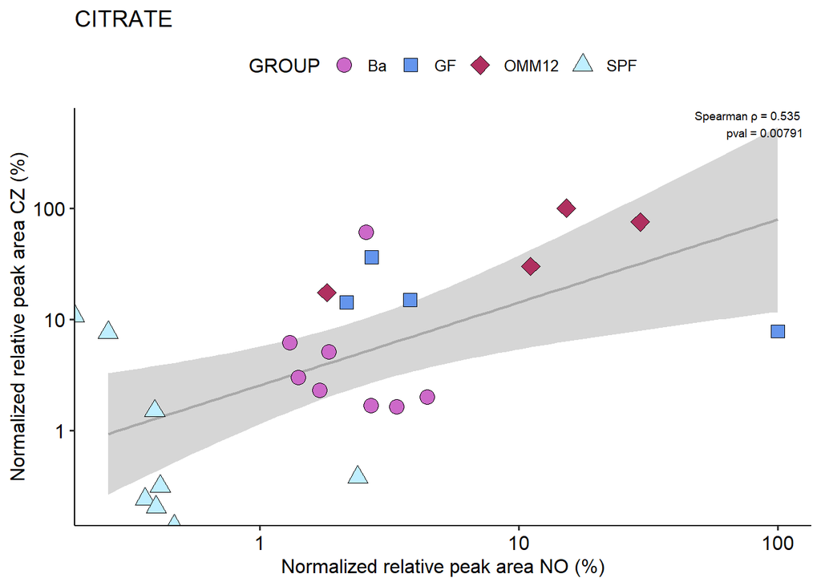

```r
ggplot(citrate, aes(x = NO, y = CZ)) +
  geom_smooth(method = "lm", linewidth = 0.8, color = "darkgrey") +
  geom_point(aes(shape = GROUP, fill = GROUP),
             color = "black",      # border colour for all points
             size = 4,
             stroke = 0.5) +       # border thickness
  theme_pubr() +
  annotate("text",
           x = Inf, y = Inf,
           label = paste0("Spearman ρ = ", cit_rho, "\npval = ", cit_pval),
           hjust = 1.1, vjust = 1.1,
           size = 2.5) +
  scale_x_log10(breaks = c(0.1, 1, 10, 100),
                labels = c("0.1", "1", "10", "100")) +
  scale_y_log10(breaks = c(0.1, 1, 10, 100),
                labels = c("0.1", "1", "10", "100")) +
  scale_shape_manual(values = c("Ba" = 21, "GF" = 22, "OMM12" = 23, "SPF" = 24)) +
  scale_fill_manual(values = c(Ba = "orchid3", GF = "cornflowerblue", OMM12 = "maroon", SPF = "lightblue1")) +
  labs(
    title = "CITRATE",
    x = "Normalized relative peak area NO (%)",
    y = "Normalized relative peak area CZ (%)")
```

Assign it to the variable Citrate_spearman and save it as a .png

```r
Citrate_spearman <-ggplot(citrate, aes(x = NO, y = CZ)) +
  geom_smooth(method = "lm", linewidth = 0.8, color = "darkgrey") +
  geom_point(aes(shape = GROUP, fill = GROUP),
             color = "black",      # border colour for all points
             size = 3,
             stroke = 0.5) +       # border thickness
  theme_pubr() +
  annotate("text",
           x = Inf, y = Inf,
           label = paste0("Spearman ρ = ", cit_rho, "\npval = ", cit_pval),
           hjust = 1.9, vjust = 1.1,
           size = 3.5) +
  scale_x_log10(breaks = c(0.1, 1, 10, 100),
                labels = c("0.1", "1", "10", "100")) +
  scale_y_log10(breaks = c(0.1, 1, 10, 100),
                labels = c("0.1", "1", "10", "100")) +
  scale_shape_manual(values = c("Ba" = 21, "GF" = 22, "OMM12" = 23, "SPF" = 24)) +
  scale_fill_manual(values = c(Ba = "orchid3", GF = "cornflowerblue", OMM12 = "maroon", SPF = "lightblue1")) +
  labs(
    title = "CITRATE",
    x = "Normalized relative peak area NO (%)",
    y = "Normalized relative peak area CZ (%)")+
    theme(
    plot.title   = element_text(size = 12, face = "bold"),
    axis.title.x = element_text(size = 10),
    axis.title.y = element_text(size = 10),
    legend.text =  element_text(size = 12)
  )
ggsave("Citrate_spearman_correlation.png",
       plot = Citrate_spearman,
       width = 10, height = 10, dpi = 300)
```

M A L A T E

Import the dataset and exclude blanks

```r
malate <- read_excel("NORWAY_QUANTIFICATION.xlsx", sheet = "NEW_MALATE") %>%
  as.data.frame() %>%
  mutate(`MEDIAN_REL_AREA_NORMALIZED` = as.numeric(`MEDIAN_REL_AREA_NORMALIZED`)) %>%
  filter(COHORT != "Blank")  # Remove rows where COHORT is "Blank"
```

Filter only valued for replicate1 in the column “Replicate” and exclude samples CV5 and CV6

```r
malate <- malate %>%
  filter(REPLICATE == "Rep1", !TYPE %in% c("CV5", "CV6"))
```

Create new column “Group”

```r
malate <- malate %>%
  mutate(GROUP = sub("_.*", "", COHORT))
```

Reshape the data matrix and extract only values for plotting

```r
malate <- malate %>%
  select(TYPE, GROUP, COUNTRY, `MEDIAN_REL_AREA_NORMALIZED`) %>%
  pivot_wider(
    names_from = COUNTRY,
    values_from = `MEDIAN_REL_AREA_NORMALIZED`
  )

malate <- malate %>%
  mutate(
    CZ = as.numeric(CZ),
    NO = as.numeric(NO)
  )
```

Add Spearman Correlation test

```r
mal_res <- cor.test(malate$NO, malate$CZ, method = "spearman")
mal_rho <- round(mal_res$estimate, 3)
mal_pval <- signif(mal_res$p.value, 3)
```

Check the correlation plot

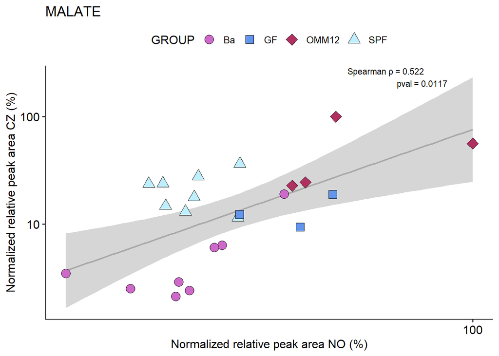

```r
ggplot(malate, aes(x = NO, y = CZ)) +
  geom_smooth(method = "lm", linewidth = 0.8, color = "darkgrey") +
  geom_point(aes(shape = GROUP, fill = GROUP),
             color = "black",      # border colour for all points
             size = 4,
             stroke = 0.5) +       # border thickness
  theme_pubr() +
  annotate("text",
           x = Inf, y = Inf,
           label = paste0("Spearman ρ = ", mal_rho, "\npval = ", mal_pval),
           hjust = 1.9, vjust = 1.1,
           size = 3) +
  scale_x_log10(breaks = c(0.1, 1, 10, 100),
                labels = c("0.1", "1", "10", "100")) +
  scale_y_log10(breaks = c(0.1, 1, 10, 100),
                labels = c("0.1", "1", "10", "100")) +
  scale_shape_manual(values = c("Ba" = 21, "GF" = 22, "OMM12" = 23, "SPF" = 24)) +
  scale_fill_manual(values = c(Ba = "orchid3", GF = "cornflowerblue", OMM12 = "maroon", SPF = "lightblue1")) +
  labs(
    title = "MALATE",
    x = "Normalized relative peak area NO (%)",
    y = "Normalized relative peak area CZ (%)")
```

Assign it to the variable Malate_spearman and save it as a .png

```r
Malate_spearman<- ggplot(malate, aes(x = NO, y = CZ)) +
  geom_smooth(method = "lm", linewidth = 0.8, color = "darkgrey") +
  geom_point(aes(shape = GROUP, fill = GROUP),
             color = "black",      # border colour for all points
             size = 3,
             stroke = 0.5) +       # border thickness
  theme_pubr() +
  annotate("text",
           x = Inf, y = Inf,
           label = paste0("Spearman ρ = ", mal_rho, "\npval = ", mal_pval),
           hjust = 1.9, vjust = 1.1,
           size = 3.5) +
  scale_x_log10(breaks = c(0.1, 1, 10, 100),
                labels = c("0.1", "1", "10", "100")) +
  scale_y_log10(breaks = c(0.1, 1, 10, 100),
                labels = c("0.1", "1", "10", "100")) +
  scale_shape_manual(values = c("Ba" = 21, "GF" = 22, "OMM12" = 23, "SPF" = 24)) +
  scale_fill_manual(values = c(Ba = "orchid3", GF = "cornflowerblue", OMM12 = "maroon", SPF = "lightblue1")) +
  labs(
    title = "MALATE",
    x = "Normalized relative peak area NO (%)",
    y = "Normalized relative peak area CZ (%)")+
    theme(
    plot.title   = element_text(size = 12, face = "bold"),
    axis.title.x = element_text(size = 10),
    axis.title.y = element_text(size = 10),
    legend.text =  element_text(size = 12)
  )
ggsave("Malate_spearman_correlation.png",
       plot = Malate_spearman,
       width = 10, height = 10, dpi = 300)
```

S U C C I N A T E

Import the dataset and exclude blanks

```r
succinate <- read_excel("NORWAY_QUANTIFICATION.xlsx", sheet = "NEW_SUCCINATE") %>%
  as.data.frame() %>%
  mutate(`MEDIAN_REL_AREA_NORMALIZED` = as.numeric(`MEDIAN_REL_AREA_NORMALIZED`)) %>%
  filter(COHORT != "Blank")  # Remove rows where COHORT is "Blank"
```

Filter only valued for replicate1 in the column “Replicate” and exclude samples CV5 and CV6

```r
succinate <- succinate %>%
  filter(REPLICATE == "Rep1", !TYPE %in% c("CV5", "CV6"))
```

Create new column “Group”

```r
succinate <- succinate %>%
  mutate(GROUP = sub("_.*", "", COHORT))
```

Reshape the data matrix and extract only values for plotting

```r
succinate <- succinate %>%
  select(TYPE, GROUP, COUNTRY, `MEDIAN_REL_AREA_NORMALIZED`) %>%
  pivot_wider(
    names_from = COUNTRY,
    values_from = `MEDIAN_REL_AREA_NORMALIZED`
  )

succinate <- succinate %>%
  mutate(
    CZ = as.numeric(CZ),
    NO = as.numeric(NO)
  )
```

Add Spearman Correlation test

```r
succ_res <- cor.test(succinate$NO, succinate$CZ, method = "spearman")
succ_rho <- round(succ_res$estimate, 3)
succ_pval <- signif(succ_res$p.value, 3)
```

Check the correlation plot

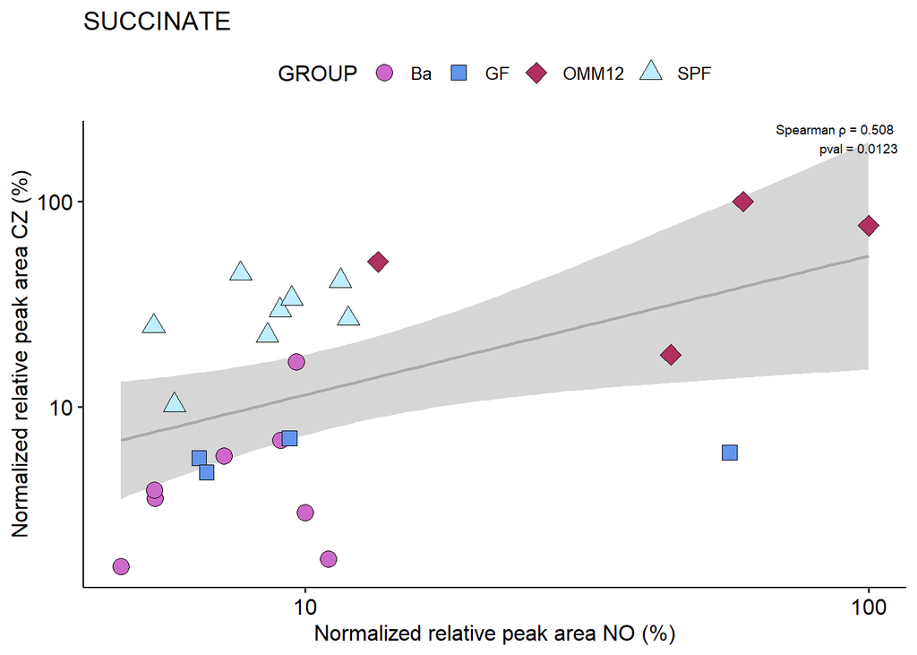

```r
ggplot(succinate, aes(x = NO, y = CZ)) +
  geom_smooth(method = "lm", linewidth = 0.8, color = "darkgrey") +
  geom_point(aes(shape = GROUP, fill = GROUP),
             color = "black",      # border colour for all points
             size = 4,
             stroke = 0.5) +       # border thickness
  theme_pubr() +
  annotate("text",
           x = Inf, y = Inf,
           label = paste0("Spearman ρ = ", succ_rho, "\npval = ", succ_pval),
           hjust = 1.1, vjust = 1.1,
           size = 2.5) +
  scale_x_log10(breaks = c(0.1, 1, 10, 100),
                labels = c("0.1", "1", "10", "100")) +
  scale_y_log10(breaks = c(0.1, 1, 10, 100),
                labels = c("0.1", "1", "10", "100")) +
  scale_shape_manual(values = c("Ba" = 21, "GF" = 22, "OMM12" = 23, "SPF" = 24)) +
  scale_fill_manual(values = c(Ba = "orchid3", GF = "cornflowerblue", OMM12 = "maroon", SPF = "lightblue1")) +
  labs(
    title = "SUCCINATE",
    x = "Normalized relative peak area NO (%)",
    y = "Normalized relative peak area CZ (%)")
```

Assign it to the variable Succinate_spearman and save it as a .png

[figure not shown]

```r
Succinate_spearman<-ggplot(succinate, aes(x = NO, y = CZ)) +
  geom_smooth(method = "lm", linewidth = 0.8, color = "darkgrey") +
  geom_point(aes(shape = GROUP, fill = GROUP),
             color = "black",      # border colour for all points
             size = 3,
             stroke = 0.5) +       # border thickness
  theme_pubr() +
  annotate("text",
           x = Inf, y = Inf,
           label = paste0("Spearman ρ = ", succ_rho, "\npval = ", succ_pval),
           hjust = 1.9, vjust = 1.1,
           size = 3.5) +
  scale_x_log10(breaks = c(0.1, 1, 10, 100),
                labels = c("0.1", "1", "10", "100")) +
  scale_y_log10(breaks = c(0.1, 1, 10, 100),
                labels = c("0.1", "1", "10", "100")) +
  scale_shape_manual(values = c("Ba" = 21, "GF" = 22, "OMM12" = 23, "SPF" = 24)) +
  scale_fill_manual(values = c(Ba = "orchid3", GF = "cornflowerblue", OMM12 = "maroon", SPF = "lightblue1")) +
  labs(
    title = "SUCCINATE",
    x = "Normalized relative peak area NO (%)",
    y = "Normalized relative peak area CZ (%)")+
    theme(
    plot.title   = element_text(size = 12, face = "bold"),
    axis.title.x = element_text(size = 10),
    axis.title.y = element_text(size = 10),
    legend.text =  element_text(size = 12)
  )
ggsave("Succinate_spearman_correlation.png",
       plot = Succinate_spearman,
       width = 10, height = 10, dpi = 300)
combined_plot <-
  (Lactate_spearman +
  Acetate_spearman +
   Propionate_spearman +
   Butyrate_spearman +
   Isobutyrate_spearman) +
   Valerate_spearman +
   Isovalerate_spearman +
   Pivalate_spearman +
   Malate_spearman +
   Citrate_spearman +
   Succinate_spearman +
  plot_layout(
    ncol = 3,
    guides = "collect"
  ) &
theme(legend.position = "bottom", legend.text =  element_text(size = 14))
combined_plot +
  plot_annotation(
    title = "Spearman correlations between normalized relative peak areas",
    subtitle = "Log10-scaled values; points colored by experimental group",
    theme = theme(
      axis.title.x = element_text(size = 8),
      axis.title.y = element_text(size = 8)
    )
  )
```

```r
all<-combined_plot +
  plot_annotation(
    #title = "Spearman correlations between normalized relative peak areas",
    #subtitle = "Log10-scaled values; points colored by experimental group",
    theme = theme(
      axis.title.x = element_text(size = 8),
      axis.title.y = element_text(size = 8)
    )
  )
ggsave("All_spearman_correlation.png",
       plot = all,
       width = 10, height = 14, dpi = 300)
```